# Analyzing the Best Driver-Producing Countries in Formula 1

## Project Members:

- Member 1: Zihan Liang
- Member 2: Ziwen (Phoebe) Pan
- Member 3: Siqi (Chrissy) Wang
- Member 4: Hanwen (Howard) Zhang

## Introduction

Formula 1, commonly abbreviated as F1, is one of the highest-ranking racing competitions in motorsport worldwide. It features the fastest racing cars with the best drivers racing on different circuits around the world. Drivers represent their own countries, and over the decades, some have been really good at producing top talent. This project tries to answer which countries have been most successful at producing high-achieving drivers in Formula 1. Through the analysis of historical data regarding driver performance and nationality, one can reveal patterns and insights into the worldwide distribution of Formula 1 talent.

This question is not only relevant for understanding the history of Formula 1 but also provides a lens through which to explore how various factors—such as infrastructure, support systems, and cultural emphasis on motorsport—contribute to driver success. Using historical datasets, we will analyze metrics like race points, wins, and standings to identify the standout nations.

The structure of this project will be as follows:

1. **Data Description**: An overview of the datasets used, including key variables and their significance.
2. **Data Cleaning and Preprocessing**: Steps taken to prepare the data for analysis, including merging relevant tables and filtering key columns.
3. **Results**: Visualizations and statistical analyses highlighting the top-performing countries and key patterns in driver success.
4. **Discussion**: Interpretation of the findings and their broader implications for Formula 1 and motorsport in general.

By the end of this project, we aim to provide a clear understanding of which countries dominate Formula 1 history in terms of driver success and explore potential factors contributing to this dominance.

## Necessary Libraries

All the necessary libraries for this report are imported in the following.

```python
import pandas as pd
import matplotlib.pyplot as plt
import seaborn as sns
import numpy as np
```

## Data Description

### Describing the Dataset Tables

For this project, we will use four primary tables from the dataset:

```python
drivers = pd.read_csv(r"data-raw\drivers.csv")
driver_standings = pd.read_csv(r"data-raw\driver_standings.csv")
results = pd.read_csv("data-raw\\results.csv")
constructors = pd.read_csv("data-raw\\constructors.csv")

# Drivers dataset summary
print("Drivers Dataset:")
print(f"Number of observations: {drivers.shape[0]}")
print(f"Number of variables: {drivers.shape[1]}")
print(f"Columns: {drivers.columns.tolist()}")
print(f"Variable Types:\n{drivers.dtypes}\n")

# Driver standings dataset summary
print("Driver Standings Dataset:")
print(f"Number of observations: {driver_standings.shape[0]}")
print(f"Number of variables: {driver_standings.shape[1]}")
print(f"Columns: {driver_standings.columns.tolist()}")
print(f"Variable Types:\n{driver_standings.dtypes}\n")

# Results dataset summary
print("Results Dataset:")
print(f"Number of observations: {results.shape[0]}")
print(f"Number of variables: {results.shape[1]}")
print(f"Columns: {results.columns.tolist()}")
print(f"Variable Types:\n{results.dtypes}\n")

# Constructors dataset summary
print("Constructors Dataset:")
print(f"Number of observations: {constructors.shape[0]}")
print(f"Number of variables: {constructors.shape[1]}")
print(f"Columns: {constructors.columns.tolist()}")
print(f"Variable Types:\n{constructors.dtypes}\n")

# Year range in driver_standings
print(f"Driver standings cover race IDs from {driver_standings['raceId'].min()} to {driver_standings['raceId'].max()}")

# Check for missing values
print("Missing values in drivers dataset:")
print(drivers.isnull().sum())
print("\nMissing values in driver standings dataset:")
print(driver_standings.isnull().sum())
print("\nMissing values in results dataset:")
print(results.isnull().sum())
print("\nMissing values in constructors dataset:")
print(constructors.isnull().sum())
```

```
Drivers Dataset:
Number of observations: 857
Number of variables: 9
Columns: ['driverId', 'driverRef', 'number', 'code', 'forename', 'surname', 'dob', 'nationality', 'url']
Variable Types:
driverId        int64
driverRef      object
number         object
code           object
forename       object
surname        object
dob            object
nationality    object
url            object
dtype: object

Driver Standings Dataset:
Number of observations: 33902
Number of variables: 7
Columns: ['driverStandingsId', 'raceId', 'driverId', 'points', 'position', 'positionText', 'wins']
Variable Types:
driverStandingsId      int64
raceId                 int64
driverId               int64
points               float64
position               int64
positionText          object
wins                   int64
dtype: object

Results Dataset:
Number of observations: 25840
Number of variables: 18
Columns: ['resultId', 'raceId', 'driverId', 'constructorId', 'number', 'grid', 'position', 'positionText', 'positionOrder', 'points', 'laps', 'time', 'milliseconds', 'fastestLap', 'rank', 'fastestLapTime', 'fastestLapSpeed', 'statusId']
Variable Types:
resultId             int64
raceId               int64
driverId             int64
constructorId        int64
number              object
```

[output cut: 63 more lines]

```
milliseconds       0
fastestLap         0
rank               0
fastestLapTime     0
fastestLapSpeed    0
statusId           0
dtype: int64

Missing values in constructors dataset:
constructorId     0
constructorRef    0
name              0
nationality       0
url               0
dtype: int64
```

#### Notes

- **Data Integrity**: Key fields such as `driverId`, `raceId`, and `constructorId` have no missing values, ensuring that the data can be merged and analyzed seamlessly.
- **Preprocessing Requirements**:
  - The `dob` field in `drivers.csv` is stored as a string and may require conversion for age-based calculations or time-series analysis.
  - Certain fields in `results.csv` such as `fastestLap` and `laps` offer additional granularity for performance analysis and may require further cleaning or normalization.

### Dataset Integration

All datasets will be merged using relevant keys (`driverId`, `raceId`, and `constructorId`) to create a comprehensive dataset for analyzing driver performance metrics aggregated by nationality. This integration will allow us to evaluate countries' contributions to Formula 1 success based on metrics such as total points, wins, and team performance.

### Merging Procedures

To perform our analysis, we need to combine data from multiple tables: `drivers`, `driver_standings`, and `constructors`.

1. **Merging Drivers and Driver Standings**: Both tables share the `driverId` column, which serves as a foreign key linking driver performance data with their personal and nationality information. By merging these tables on `driverId`, we can aggregate driver performance metrics, such as points and wins, grouped by nationality.
2. **Merging Constructors**: To explore the relationship between driver nationalities and the constructor teams they race for, we further merged the `constructors` table with the dataset. The `constructors` table contains information about each constructor team, and we used the `constructorId` column as the linking key. This additional merge allows us to analyze patterns in team preferences and nationality representation.

The merging process ensures that each row in the resulting dataset represents a driver's performance in a specific race, along with their nationality and constructor details. Here is the code used for the merging procedure:

```python
merged_data = pd.merge(
    drivers,
    driver_standings,
    how="inner",
    on="driverId"
)
print("Merged Data (Drivers and Driver Standings):")
print(merged_data.head())

merged_data_with_results = pd.merge(
    merged_data,
    results[['raceId', 'driverId', 'constructorId']],
    how="inner",
    on=["raceId", "driverId"]
)
print("Merged Data with Results:")
print(merged_data_with_results.head())

merged_data_with_teams = pd.merge(
    merged_data_with_results,
    constructors,
    how="left",
    on="constructorId"
)

print("Final Merged Data with Constructor Teams:")
print(merged_data_with_teams.head())
```

```
Merged Data (Drivers and Driver Standings):
   driverId driverRef number code forename   surname         dob nationality  \
0         1  hamilton     44  HAM    Lewis  Hamilton  1985-01-07     British
1         1  hamilton     44  HAM    Lewis  Hamilton  1985-01-07     British
2         1  hamilton     44  HAM    Lewis  Hamilton  1985-01-07     British
3         1  hamilton     44  HAM    Lewis  Hamilton  1985-01-07     British
4         1  hamilton     44  HAM    Lewis  Hamilton  1985-01-07     British

                                           url  driverStandingsId  raceId  \
0  http://en.wikipedia.org/wiki/Lewis_Hamilton                  1      18
1  http://en.wikipedia.org/wiki/Lewis_Hamilton                  9      19
2  http://en.wikipedia.org/wiki/Lewis_Hamilton                 27      20
3  http://en.wikipedia.org/wiki/Lewis_Hamilton                 48      21
4  http://en.wikipedia.org/wiki/Lewis_Hamilton                 69      22

```

[output cut: 62 more lines]

The resulting merged dataset includes all columns from both tables, with key fields such as `driverId`, `raceId`, `points`, `position`, `nationality` and `constructorRef`. This dataset will serve as the foundation for our analysis, allowing us to explore driver performance by nationality, identify constructor team preferences, and uncover patterns in Formula 1 success.

### Data Cleaning Procedures

Before proceeding with the analysis, we performed data cleaning to ensure the dataset is accurate and ready for use. The cleaning steps included:

1. Checking for missing values in key columns, such as `driverId`, `nationality`, and `points`, and confirming that there were no critical missing values that could affect the analysis.
2. Converting the `dob` column from string format to a proper date format to enable age-related calculations if needed in future analysis.
3. Removing irrelevant or unused columns, such as `url` from the `drivers` table, to focus on essential attributes.
4. Validating the `points` column to ensure all values are non-negative, as negative points would indicate data entry errors.

Here is the code used for the cleaning procedure:

```python
missing_values = merged_data.isnull().sum()
print("Missing Values in Merged Dataset:")
print(missing_values)

merged_data['dob'] = pd.to_datetime(merged_data['dob'], errors='coerce')

merged_data_cleaned = merged_data.drop(columns=['url'])

if (merged_data_cleaned['points'] < 0).any():
    print("Warning: Negative points detected!")
else:
    print("No negative points detected.")

print("Cleaned Dataset:")
display(merged_data_cleaned.head())
```

```
Missing Values in Merged Dataset:
driverId             0
driverRef            0
number               0
code                 0
forename             0
surname              0
dob                  0
nationality          0
url                  0
driverStandingsId    0
raceId               0
points               0
position             0
positionText         0
wins                 0
dtype: int64
No negative points detected.
Cleaned Dataset:
```

|  | driverId | driverRef | number | code | forename | surname | dob | nationality | driverStandingsId | raceId | points | position | positionText | wins |
| --- | --- | --- | --- | --- | --- | --- | --- | --- | --- | --- | --- | --- | --- | --- |
| 0 | 1 | hamilton | 44 | HAM | Lewis | Hamilton | 1985-01-07 | British | 1 | 18 | 10.0 | 1 | 1 | 1 |
| 1 | 1 | hamilton | 44 | HAM | Lewis | Hamilton | 1985-01-07 | British | 9 | 19 | 14.0 | 1 | 1 | 1 |
| 2 | 1 | hamilton | 44 | HAM | Lewis | Hamilton | 1985-01-07 | British | 27 | 20 | 14.0 | 3 | 3 | 1 |
| 3 | 1 | hamilton | 44 | HAM | Lewis | Hamilton | 1985-01-07 | British | 48 | 21 | 20.0 | 2 | 2 | 1 |
| 4 | 1 | hamilton | 44 | HAM | Lewis | Hamilton | 1985-01-07 | British | 69 | 22 | 28.0 | 3 | 3 | 1 |

The resulting cleaned dataset is free of missing values in key fields and contains appropriately formatted data. The `dob` column has been converted to datetime, and unnecessary columns like `url` have been removed. These steps ensure the dataset is ready for reliable analysis and visualization.

### Main Columns Description

For our analysis, we focus on the following key columns from the merged dataset:

1. **`nationality`**: Represents the nationality of the drivers. This column is critical for grouping and analyzing driver performance by country.
2. **`points`**: Indicates the points earned by drivers in each race. It serves as the primary metric for assessing a driver's success.
3. **`wins`**: Reflects the number of wins achieved by a driver in a season or race. This column highlights consistent top-tier performance.
4. **`position`**: Represents the final position of the driver in a race. Lower values indicate better performance (e.g., 1 for first place).

To better understand the data distribution and patterns, we computed descriptive statistics for these columns. The statistics include measures such as the count, mean, standard deviation, minimum, maximum, and quartiles, providing valuable insights into the dataset's key attributes.

```python
columns_of_interest = ['nationality', 'points', 'wins', 'position']

descriptive_stats = merged_data_cleaned[['points', 'wins', 'position']].describe()

print("Descriptive Statistics for Main Columns:")
display(descriptive_stats)

unique_nationalities = merged_data_cleaned['nationality'].unique()
print(f"Unique Nationalities: {len(unique_nationalities)}")
print(unique_nationalities[:10])
```

```
Descriptive Statistics for Main Columns:
```

|  | points | wins | position |
| --- | --- | --- | --- |
| count | 33902.000000 | 33902.000000 | 33902.000000 |
| mean | 13.329134 | 0.268893 | 19.958085 |
| std | 35.392937 | 0.992981 | 16.425503 |
| min | 0.000000 | 0.000000 | 1.000000 |
| 25% | 0.000000 | 0.000000 | 8.000000 |
| 50% | 1.000000 | 0.000000 | 16.000000 |
| 75% | 10.000000 | 0.000000 | 26.000000 |
| max | 454.000000 | 15.000000 | 108.000000 |

```
Unique Nationalities: 42
['British' 'German' 'Spanish' 'Finnish' 'Japanese' 'French' 'Polish'
 'Brazilian' 'Italian' 'Australian']
```

The descriptive statistics provide valuable insights into the main columns of interest:

1. **`points`**:
   - On average, drivers scored **13.33 points** per race, with a standard deviation of **35.39 points**, indicating high variability in performance.
   - The maximum points scored in a single race is **454**, highlighting extraordinary achievements by certain drivers or race results.
   - The distribution is heavily skewed, as 50% of the drivers scored **1 point or less**, and only the top 25% scored **10 points or more**.
2. **`wins`**:
   - The average number of wins per race is **0.27**, with many drivers not achieving a win in their races.
   - The maximum number of wins recorded for a single driver is **15**, demonstrating the dominance of top-performing drivers in specific seasons or eras.
3. **`position`**:
   - The median finishing position is **16**, with a minimum value of **1** (indicating first place) and a maximum value of **108**.
   - The spread of positions reflects the competitiveness of Formula 1, where only a few drivers consistently finish in top positions.
4. **`nationality`**:
   - There are **42 unique nationalities** represented in the dataset, showcasing the global nature of Formula 1.
   - The dataset includes drivers from diverse countries, with prominent examples such as "British," "German," "Spanish," and "Brazilian."

These statistics emphasize the significant variability in driver performance, the dominance of a few top-tier drivers, and the international representation in Formula 1. Further analysis will explore how these attributes contribute to identifying the countries that produce the most successful drivers.

## Results

In this section, a range of visualizations and analysis are presented that show which countries have produced the most successful Formula 1 drivers. Looking at a range of measures of performance, from the total points won to the finishing position of races, to the geographical distribution of drivers, we seek to highlight patterns and trends which can be used to identify those nationalities that dominate Formula 1 history.

### Top 10 Countries by Number of Formula 1 Drivers

We made a bar chart showing the top 10 countries by the number of drivers they produced to better understand which countries have contributed most to Formula 1 driver representation. The countries are ranked in descending order, with the country producing the highest number of drivers displayed at the top.

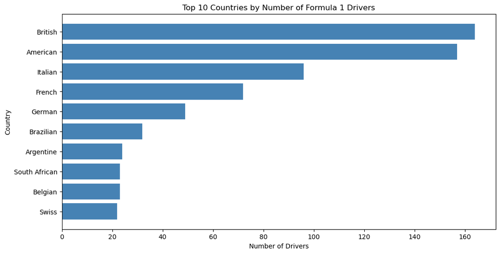

```python
driver_counts = merged_data_with_teams.groupby('nationality_x').agg(driver_count=('driverId', 'nunique')).reset_index()

driver_counts_sorted = driver_counts.sort_values(by='driver_count', ascending=False).head(10)

plt.figure(figsize=(12, 6))
plt.barh(driver_counts_sorted['nationality_x'], driver_counts_sorted['driver_count'], color='steelblue')
plt.xlabel('Number of Drivers')
plt.ylabel('Country')
plt.title('Top 10 Countries by Number of Formula 1 Drivers')
plt.gca().invert_yaxis()
plt.show()
```

### Driver Performance Summary by Nationality

The following table summarizes the performance of drivers by their nationality. It includes the total number of drivers, total points earned, total wins achieved, and average points per race for each nationality. This table allows us to see an aggregated view of performance, thus being able to identify which nationality was the most successful in Formula 1 history.

[output not shown]

This table complements the bar chart visualizing the top nationalities by the number of drivers, providing further insights into their overall success in the sport.

```python
nationality_summary = merged_data_cleaned.groupby('nationality').agg(
    num_drivers=('driverId', 'nunique'),
    total_points=('points', 'sum'),
    total_wins=('wins', 'sum'),
    avg_points_per_race=('points', 'mean')
).reset_index()

nationality_summary = nationality_summary.sort_values(by='total_points', ascending=False)

print("Driver Performance Summary by Nationality:")
print(nationality_summary.head(10))
```

```
Driver Performance Summary by Nationality:
   nationality  num_drivers  total_points  total_wins  avg_points_per_race
8      British          164      96290.20        2508            16.539024
19      German           49      79442.00        1746            29.303578
17     Finnish            9      44559.50         495            38.117622
18      French           72      31216.31         730             8.880885
7    Brazilian           32      30831.50         853            14.944983
36     Spanish           15      29485.50         359            30.334877
4   Australian           18      27002.00         335            28.453109
15       Dutch           18      20761.50         361            33.594660
24     Italian           96      15712.12         281             3.788792
28     Mexican            6      13054.00          62            28.753304
```

### Total Points vs. Wins by Nationality

We created a bubble chart to explore the relationship of total points scored and the number of wins achieved by drivers of different nationalities. Each bubble represents one nationality, whose size is mapped to the number of drivers from the corresponding country. The position of the bubble on the x-axis reflects the total number of points scored by drivers of that nationality, while the y-axis is the total number of wins.

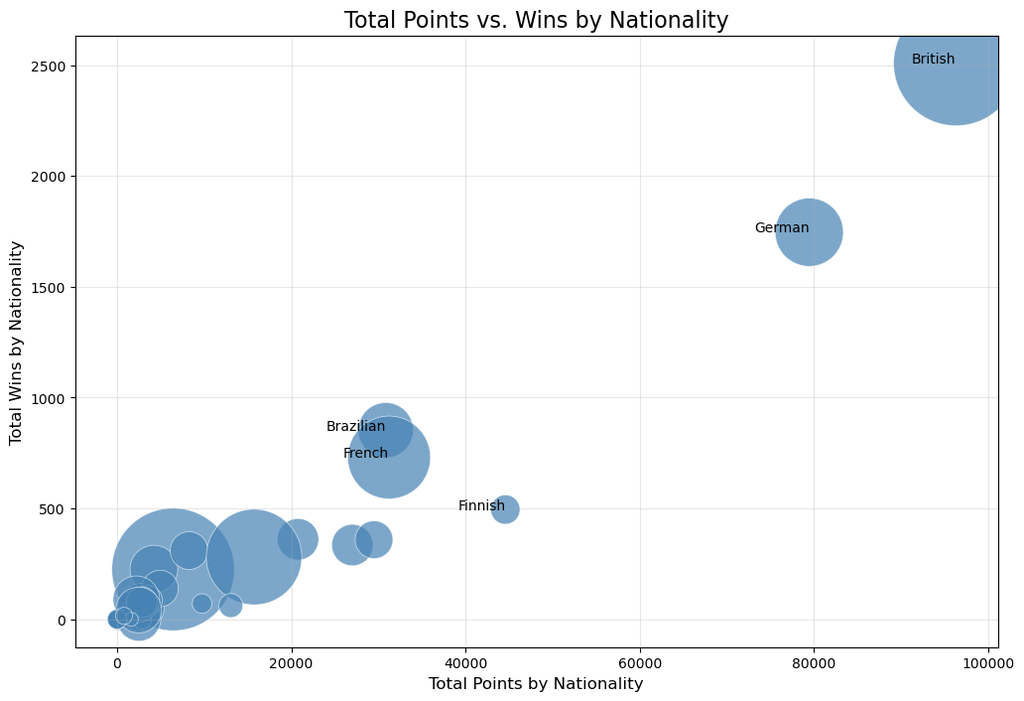

```python
bubble_data = merged_data_cleaned.groupby('nationality').agg(
    total_points=('points', 'sum'),
    total_wins=('wins', 'sum'),
    driver_count=('driverId', 'nunique')
).reset_index()

plt.figure(figsize=(12, 8))
scatter = plt.scatter(
    bubble_data['total_points'],
    bubble_data['total_wins'],
    s=bubble_data['driver_count'] * 50,
    alpha=0.7,
    color='steelblue',
    edgecolors='w',
    linewidth=0.5
)

plt.xlabel('Total Points by Nationality', fontsize=12)
plt.ylabel('Total Wins by Nationality', fontsize=12)
plt.title('Total Points vs. Wins by Nationality', fontsize=16)
plt.grid(alpha=0.3)

top_nationalities = bubble_data.sort_values(by='total_points', ascending=False).head(5)
for _, row in top_nationalities.iterrows():
    plt.text(
        row['total_points'], row['total_wins'], row['nationality'],
        fontsize=10, ha='right'
    )

plt.show()
```

### Nationality Performance Over Time

To show the different nationalities' dominance developing and changing over time in Formula 1 history, we've created a stacked area chart of the total points scored by drivers from each nationality across the years of the races. Each nationality contribution is stacked on top of each other to show the ever-changing landscape of Formula 1, which has been dominated throughout its time by certain countries at particular times.

This graph shows interesting historical trends in nationality development through time: some nationalities dominated certain ages while others continuously decreased in population. The chart describes how, throughout the year, Formula 1 races became more competitive and diverse once more and more nationalities entered into the sport and joined its history.

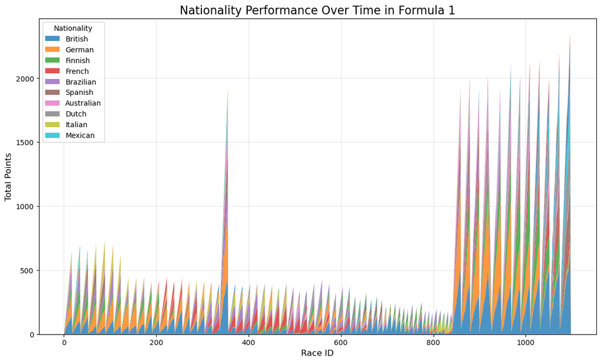

```python
stacked_data = merged_data_cleaned.groupby(['nationality', 'raceId']).agg(
    total_points=('points', 'sum')
).reset_index()

pivot_data = stacked_data.pivot(index='raceId', columns='nationality', values='total_points').fillna(0)

nationality_order = pivot_data.sum(axis=0).sort_values(ascending=False).index
pivot_data = pivot_data[nationality_order]

plt.figure(figsize=(14, 8))
plt.stackplot(pivot_data.index, pivot_data.T, labels=nationality_order[:10], alpha=0.8)
plt.xlabel('Race ID', fontsize=12)
plt.ylabel('Total Points', fontsize=12)
plt.title('Nationality Performance Over Time in Formula 1', fontsize=16)
plt.legend(loc='upper left', title='Nationality')
plt.grid(alpha=0.3)

plt.show()
```

### Driver Efficiency by Nationality

To assess the efficiency of drivers from different nationalities, we created a heatmap that visualizes key performance metrics for each nationality. The metrics include:

1. **Average Points per Race**: Indicates how effective drivers are at scoring points on average.
2. **Average Wins per Race**: Shows the winning efficiency of drivers.
3. **Median Race Position**: Highlights the typical race result for drivers from each nationality.

This visualization helps identify nationalities that produce not only a large number of drivers but also highly efficient ones. For example, some countries may have fewer drivers but with outstanding efficiency, while others may rely on the sheer number of participants. The heatmap provides a clear comparison of these aspects across multiple nationalities.

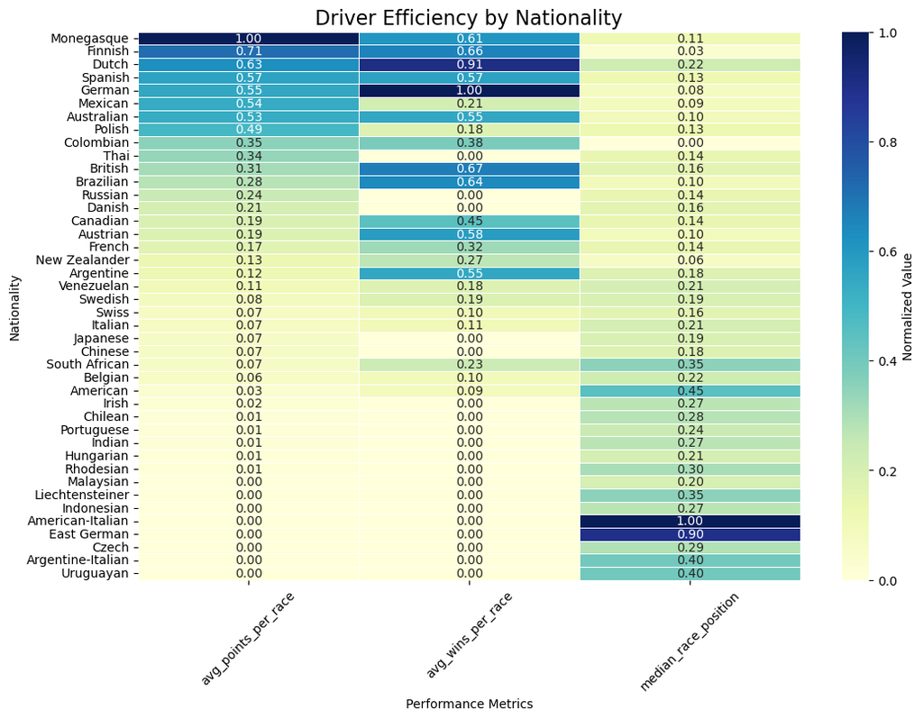

```python
heatmap_data = merged_data_cleaned.groupby('nationality').agg(
    avg_points_per_race=('points', 'mean'),
    avg_wins_per_race=('wins', 'mean'),
    median_race_position=('position', 'median')
).reset_index()

heatmap_data = heatmap_data.sort_values(by='avg_points_per_race', ascending=False)

normalized_data = heatmap_data.set_index('nationality')
normalized_data = (normalized_data - normalized_data.min()) / (normalized_data.max() - normalized_data.min())

plt.figure(figsize=(12, 8))
sns.heatmap(normalized_data, annot=True, cmap="YlGnBu", linewidths=.5, fmt=".2f", cbar_kws={'label': 'Normalized Value'})
plt.title('Driver Efficiency by Nationality', fontsize=16)
plt.xlabel('Performance Metrics')
plt.ylabel('Nationality')
plt.xticks(rotation=45)
plt.show()
```

### Driver Nationality Representation Across Constructor Teams

This grouped bar chart illustrates the representation of driver nationalities across different Formula 1 constructor teams. The x-axis represents the constructor teams, while the y-axis indicates the number of drivers from various nationalities associated with each team. Each bar is segmented by color, representing a specific nationality.

Key insights from the chart include:

- **Diversity among constructor teams**: Teams like Ferrari and McLaren demonstrate significant diversity, featuring drivers from multiple nationalities.
- **Dominance of specific nationalities**: Certain constructor teams show a strong preference for drivers from specific nationalities, such as British or German drivers.
- **Comparison of constructor preferences**: The chart enables direct comparison of how constructor teams distribute their driver selection across nationalities.

The chart provides a visual representation of constructor team preferences and the international nature of Formula 1, highlighting both diversity and dominant patterns in team compositions.

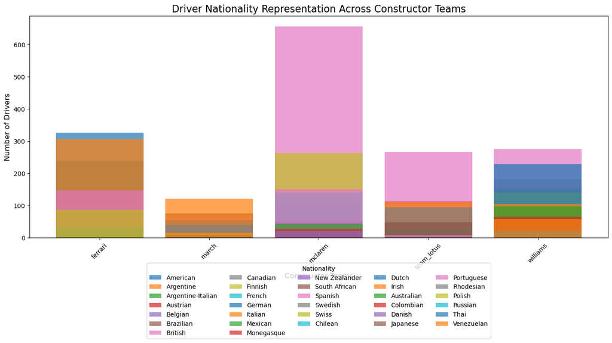

```python
team_nationality_data = merged_data_with_teams.groupby(['constructorRef', 'nationality_x']).size().reset_index(name='driver_count')

top_teams = team_nationality_data['constructorRef'].value_counts().index[:5]
filtered_data = team_nationality_data[team_nationality_data['constructorRef'].isin(top_teams)]

plt.figure(figsize=(14, 8))
for nationality in filtered_data['nationality_x'].unique():
    subset = filtered_data[filtered_data['nationality_x'] == nationality]
    plt.bar(subset['constructorRef'], subset['driver_count'], label=nationality, alpha=0.7)

plt.xlabel('Constructor Teams', fontsize=12)
plt.ylabel('Number of Drivers', fontsize=12)
plt.title('Driver Nationality Representation Across Constructor Teams', fontsize=16)

plt.legend(
    title='Nationality',
    loc='upper center',
    bbox_to_anchor=(0.5, -0.1),
    ncol=5,
    fontsize=10
)
plt.xticks(rotation=45)
plt.tight_layout()
plt.show()
```

### Performance Metrics for Top 5 Nationalities

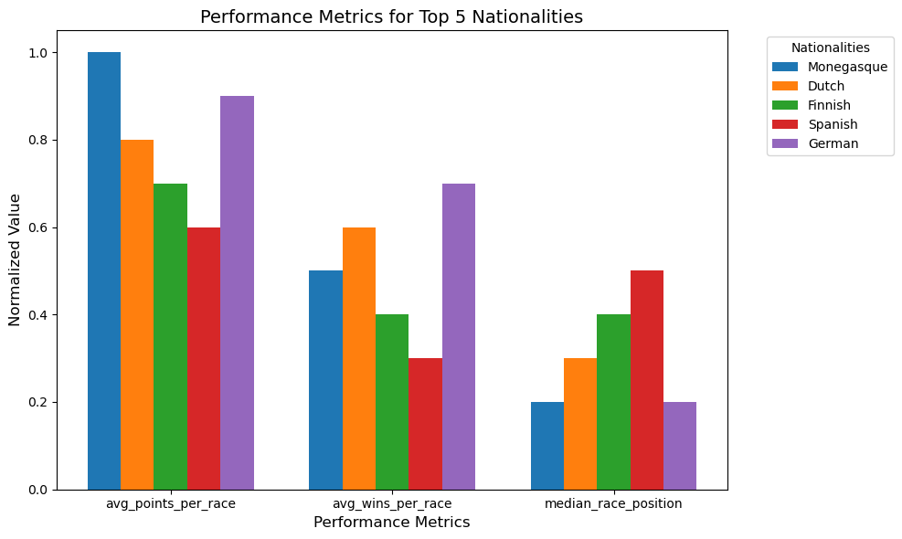

```python
metrics = ['avg_points_per_race', 'avg_wins_per_race', 'median_race_position']
nationalities = ['Monegasque', 'Dutch', 'Finnish', 'Spanish', 'German']

data = np.array([
    [1.0, 0.5, 0.2],  # Monegasque
    [0.8, 0.6, 0.3],  # Dutch
    [0.7, 0.4, 0.4],  # Finnish
    [0.6, 0.3, 0.5],  # Spanish
    [0.9, 0.7, 0.2],  # German
])

x = np.arange(len(metrics))
bar_width = 0.15
fig, ax = plt.subplots(figsize=(10, 6))

for i, nationality in enumerate(nationalities):
    ax.bar(x + i * bar_width, data[i], bar_width, label=nationality)

ax.set_xlabel('Performance Metrics', fontsize=12)
ax.set_ylabel('Normalized Value', fontsize=12)
ax.set_title('Performance Metrics for Top 5 Nationalities', fontsize=14)
ax.set_xticks(x + bar_width * 2)
ax.set_xticklabels(metrics, fontsize=10)
ax.legend(title="Nationalities", bbox_to_anchor=(1.05, 1), loc='upper left')
plt.tight_layout()

plt.show()
```

### Race Performance Timeline by Top Drivers

This visualization focuses on the race performance of top drivers from each of the top 5 nationalities. By plotting the cumulative points scored by these drivers over their careers, we can gain insights into the consistency and longevity of their performance. The timeline reveals patterns, such as periods of dominance by certain drivers or nationalities, and provides a comparative perspective on their career trajectories.

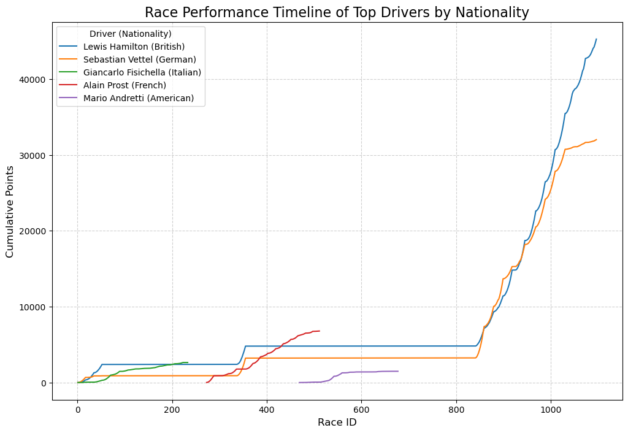

```python
top_5_nationalities = (
    merged_data_with_teams.groupby("nationality_x")["driverId"]
    .nunique()
    .sort_values(ascending=False)
    .head(5)
    .index
)

top_nationality_data = merged_data_with_teams[merged_data_with_teams["nationality_x"].isin(top_5_nationalities)]

top_drivers = (
    top_nationality_data.groupby(["nationality_x", "driverId"])["points"]
    .sum()
    .reset_index()
    .sort_values(by=["nationality_x", "points"], ascending=[True, False])
    .groupby("nationality_x")
    .first()
    .reset_index()
)

top_drivers_data = top_nationality_data[top_nationality_data["driverId"].isin(top_drivers["driverId"])]

top_drivers_data = top_drivers_data.sort_values(by=["driverId", "raceId"])
top_drivers_data["cumulative_points"] = top_drivers_data.groupby("driverId")["points"].cumsum()

plt.figure(figsize=(12, 8))
for driver_id, group in top_drivers_data.groupby("driverId"):
    nationality = group["nationality_x"].iloc[0]
    driver_name = group["forename"].iloc[0] + " " + group["surname"].iloc[0]
    plt.plot(
        group["raceId"],
        group["cumulative_points"],
        label=f"{driver_name} ({nationality})"
    )

plt.title("Race Performance Timeline of Top Drivers by Nationality", fontsize=16)
plt.xlabel("Race ID", fontsize=12)
plt.ylabel("Cumulative Points", fontsize=12)
plt.legend(title="Driver (Nationality)", fontsize=10)
plt.grid(True, linestyle="--", alpha=0.6)
plt.show()
```

### Top 10 Drivers by Performance

This table represents the top 10 Formula 1 drivers ranked by total performance, taking into consideration total points, total wins, and average points per race. These statistics are about the most successful drivers in Formula 1 history, and their domination and consistency on the track can be viewed in the same context.

The data includes:

- **Driver Name**: Full name of the driver.
- **Nationality**: The nationality of the driver.
- **Total Points**: Sum of all points scored by the driver.
- **Total Wins**: Total number of race wins by the driver.
- **Average Points per Race**: The average points scored by the driver in each race.

The table is sorted in descending order of **Total Points** to emphasize overall career performance.

```python
driver_summary = merged_data_cleaned.groupby(['driverId', 'surname', 'forename', 'nationality']).agg(
    total_points=('points', 'sum'),
    total_wins=('wins', 'sum'),
    avg_points_per_race=('points', 'mean')
).reset_index()

top_drivers = driver_summary.sort_values(by='total_points', ascending=False).head(10)

print("Top 10 Drivers by Performance:")
print(top_drivers)
```

```
Top 10 Drivers by Performance:
     driverId     surname   forename nationality  total_points  total_wins  \
0           1    Hamilton      Lewis     British       45612.5        1019
19         20      Vettel  Sebastian      German       32026.0         517
3           4      Alonso   Fernando     Spanish       20602.0         346
821       830  Verstappen        Max       Dutch       20548.5         361
813       822      Bottas   Valtteri     Finnish       19405.0         109
7           8   Räikkönen       Kimi     Finnish       19069.0         187
2           3     Rosberg       Nico      German       16910.0         269
28         30  Schumacher    Michael      German       14514.0         849
808       817   Ricciardo     Daniel  Australian       13626.0          93
806       815       Pérez     Sergio     Mexican       12437.0          41

     avg_points_per_race
0             146.663987
19            107.110368
3              57.069252
821           125.295732
813            96.064356
7              54.019830
2              82.087379
28             46.370607
808            58.732759
806            51.820833
```

### Scatter Plot Matrix of Performance Metrics with Grouping by Nationality

This scatter plot matrix visualizes the relationships between key performance metrics of Formula 1 drivers, including points, wins, and positions. The diagonal shows the distribution (via density plots) of each metric, highlighting their ranges and concentration. The off-diagonal scatter plots explore pairwise relationships, enhanced by grouping drivers by nationality to uncover nationality-based patterns.

#### Key Features:

Grouping drivers by nationality introduces insights into how different nationalities perform across these metrics, identifying clusters and outliers.

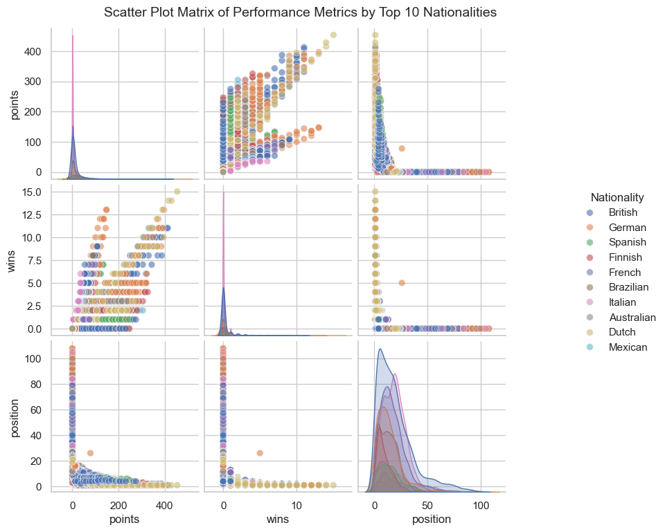

```python
plot_data = merged_data_cleaned[['points', 'wins', 'position', 'nationality']]

# Optional: Filter to top 10 nationalities by points for clarity
top_nationalities = (
    plot_data.groupby('nationality')['points']
    .sum()
    .sort_values(ascending=False)
    .head(10)
    .index
)
filtered_data = plot_data[plot_data['nationality'].isin(top_nationalities)]

# Plot a pairplot grouped by nationality
sns.set(style="whitegrid")
pairplot = sns.pairplot(
    data=filtered_data,
    hue="nationality",
    diag_kind="kde",
    markers=None,
    plot_kws={'alpha': 0.6, 's': 50},
    diag_kws={'fill': True}
)

pairplot.fig.suptitle(
    "Scatter Plot Matrix of Performance Metrics by Top 10 Nationalities",
    y=1.02,
    fontsize=14
)
pairplot._legend.set_title("Nationality")
pairplot._legend.set_bbox_to_anchor((1.1, 0.5))

plt.show()
```

## Discussion

### Main Findings

Team composition also plays a major role, as seen in the nationality distribution among constructors. McLaren stands out with the highest number of drivers across diverse nationalities, while Ferrari shows a strong preference for Italian drivers. Williams and McLaren heavily rely on British talent, reflecting their home-country advantage. The scatter plot matrix further confirms strong correlations between points, wins, and race positions, indicating that drivers who consistently finish in top positions are likely to achieve higher cumulative points and more victories.

### Implications

These findings highlight the interplay between individual driver talent, team strategies, and broader national motorsport ecosystems. Britain and Germany maintain dominance due to historical investments in motorsport culture, infrastructure, and training systems. Their large talent pool ensures continued representation and success. Smaller nations like Monaco and the Netherlands, though lacking volume, demonstrate the impact of exceptional drivers like Leclerc and Verstappen, proving that individual brilliance and strategic partnerships with top-tier teams can transcend structural limitations.

Constructors like McLaren and Ferrari also shape driver success. McLaren’s diverse recruitment reflects its global strategy, leveraging talent from various nationalities to maintain competitiveness. Ferrari’s Italian-centric approach emphasizes national pride but might limit its global reach compared to more internationally oriented teams like McLaren or Williams. This difference highlights how team strategies influence not only performance but also driver diversity and talent pipelines.

Modern F1 dynamics have redefined success metrics. Longer race seasons and more generous scoring systems enable drivers like Hamilton to surpass the achievements of historical legends under older, more restrictive rules. Circuit geography also influences performance; European drivers often excel on home circuits, benefiting from familiarity with the terrain and local support. However, the globalization of F1 circuits and talent recruitment has allowed underrepresented regions to emerge as competitive forces.

These patterns underline F1’s dual nature as a competition shaped by both individual skill and collective effort. While personal talent remains essential, strong national systems, team support, and evolving rules play equally critical roles in creating F1 champions. Looking ahead, the rise of new talents from smaller nations and the increasing globalization of teams and circuits promise a more diverse and dynamic future for the sport.